# Small Volume Lipoprotein (a) Isolation Guide for Clinical Research: Proteomics Data Analysis

P Bergstrom

December 18, 2020

```r
library(ggplot2, quietly = TRUE)
library(RColorBrewer, quietly = TRUE)
library(pheatmap, quietly = TRUE)
library(dplyr, quietly = TRUE)
library(kableExtra, quietly = TRUE)
library(grid, quietly = TRUE)
library(edgeR, quietly = TRUE)
library(ggrepel, quietly = TRUE)
library(ggbiplot, quietly = TRUE)
library(eulerr, quietly = TRUE)
library(mclust, quietly = TRUE)
library(psych, quietly = TRUE)
library(readxl, quietly = TRUE)
library(reshape2, quietly = TRUE)
library(limma, quietly = TRUE)
library(ggfortify, quietly = TRUE)
library(extrafont, quietly = TRUE)
```

## Results

Protein list trimmed to exclude any proteins that did not appear in at least 75% of samples from at least one lipoprotein compartment.

```r
# importing lipoprotein fraction proteomics
lpa_75 <- read_excel("Lp(a) small volume isolation proteomics.xlsx", sheet="Working list", col_names=TRUE)
# replace 0s with NA for display
lpa_NA <- lpa_75
lpa_NA[lpa_NA == 0] <- NA
# writing a scrollable embedded html table
kable(lpa_NA, "html") %>% kable_styling("striped") %>% scroll_box(height="350px")
```

| Protein | VLDL 001 | VLDL 002 | VLDL 003 | VLDL 007 | VLDL 006 | VLDL 004 | LDL 004 | LDL 001 | LDL 002 | LDL 003 | LDL 007 | LDL 006 | LDL 005 | LDL 008 | LDL 009 | HDL 001 | HDL 002 | HDL 003 | HDL 004 | HDL 007 | HDL 005 | HDL 008 | HDL 009 | Lp(a) 001 | Lp(a) 002 | Lp(a) 003 | Lp(a) 004 | Lp(a) 006 | Lp(a) 005 |
| --- | --- | --- | --- | --- | --- | --- | --- | --- | --- | --- | --- | --- | --- | --- | --- | --- | --- | --- | --- | --- | --- | --- | --- | --- | --- | --- | --- | --- | --- |
| IGKC | NA | 0.0007248 | NA | NA | 0.0005402 | 0.0029226 | 0.0028539 | 0.0029098 | 0.0017811 | NA | 0.0004072 | NA | 0.0016183 | 0.0021952 | 0.0038764 | 0.0011117 | 0.0020278 | NA | 0.0012535 | NA | 0.0006826 | NA | NA | 0.0004726 | NA | NA | 0.0020166 | 0.0010919 | NA |
| IGHG2 | NA | NA | NA | NA | NA | 0.0024355 | 0.0037100 | 0.0023278 | 0.0017811 | NA | 0.0004072 | 0.0010321 | 0.0006743 | 0.0022950 | 0.0045812 | 0.0013897 | 0.0005794 | NA | NA | NA | NA | NA | NA | 0.0007089 | 0.0006441 | NA | 0.0007562 | 0.0008736 | NA |
| HBB | NA | NA | NA | NA | NA | NA | 0.0011416 | NA | 0.0007916 | 0.0006496 | 0.0040721 | 0.0017694 | 0.0017532 | 0.0017960 | 0.0018795 | 0.0041690 | NA | NA | NA | 0.0010780 | NA | 0.0013123 | 0.0014060 | NA | NA | NA | 0.0010083 | NA | NA |
| IGHM | NA | NA | NA | NA | NA | 0.0009742 | 0.0028539 | 0.0046557 | NA | NA | 0.0010180 | 0.0004423 | 0.0012138 | 0.0016963 | 0.0019969 | 0.0022235 | 0.0026072 | NA | NA | NA | NA | NA | NA | NA | NA | NA | NA | NA | NA |
| GC | NA | NA | NA | NA | NA | NA | 0.0018550 | 0.0007759 | 0.0017811 | NA | 0.0003054 | 0.0004423 | 0.0006743 | 0.0015965 | 0.0016445 | 0.0011117 | NA | NA | NA | NA | NA | NA | NA | NA | NA | NA | NA | 0.0017471 | NA |
| HPX | NA | NA | NA | NA | NA | NA | 0.0032820 | 0.0017459 | 0.0035622 | NA | 0.0011198 | 0.0017694 | 0.0014835 | 0.0020954 | 0.0024668 | NA | NA | NA | NA | NA | NA | NA | NA | NA | 0.0006441 | NA | NA | 0.0039310 | NA |
| ITIH2 | NA | NA | NA | NA | NA | NA | 0.0009989 | 0.0032978 | 0.0005937 | NA | NA | 0.0002949 | 0.0004046 | 0.0010976 | 0.0014096 | 0.0008338 | 0.0011587 | 0.0023989 | NA | NA | NA | NA | NA | NA | NA | NA | NA | NA | NA |
| TLN1 | NA | NA | NA | NA | NA | NA | 0.0172660 | NA | 0.0003958 | NA | 0.0271811 | 0.0179888 | 0.0183412 | 0.0183596 | 0.0183249 | NA | NA | NA | 0.0009401 | NA | 0.0020478 | NA | 0.0021090 | NA | NA | NA | NA | NA | NA |
| SERPINC1 | NA | NA | NA | NA | NA | NA | 0.0015696 | 0.0007759 | 0.0013853 | NA | 0.0003054 | 0.0005898 | 0.0002697 | 0.0016963 | 0.0016445 | NA | NA | NA | NA | NA | NA | NA | NA | NA | NA | NA | NA | 0.0008736 | NA |
| HBD | NA | NA | NA | NA | NA | NA | 0.0008562 | NA | 0.0003958 | NA | 0.0021378 | 0.0008847 | 0.0010789 | 0.0009978 | 0.0009397 | 0.0013897 | NA | NA | NA | NA | NA | NA | NA | NA | NA | NA | 0.0007562 | NA | NA |
| VCL | NA | NA | NA | NA | NA | NA | 0.0059932 | NA | 0.0003958 | NA | 0.0067189 | 0.0054556 | 0.0066082 | 0.0062862 | 0.0063432 | NA | NA | NA | NA | NA | NA | NA | NA | NA | NA | NA | NA | NA | NA |
| PON3 | NA | 0.0004832 | NA | NA | NA | NA | 0.0002854 | 0.0003880 | 0.0003958 | NA | NA | 0.0002949 | 0.0002697 | 0.0001996 | NA | 0.0016676 | 0.0020278 | 0.0017135 | 0.0037606 | 0.0050305 | 0.0051195 | 0.0036089 | 0.0049209 | NA | NA | 0.0004200 | NA | 0.0004368 | 0.0004742 |
| APOF | NA | NA | NA | NA | NA | NA | NA | 0.0003880 | 0.0009895 | 0.0012993 | NA | 0.0008847 | NA | 0.0004989 | 0.0003524 | 0.0005559 | 0.0014484 | 0.0010281 | 0.0012535 | NA | 0.0006826 | 0.0016404 | 0.0010545 | 0.0007089 | NA | 0.0004200 | NA | NA | NA |
| PLTP | NA | NA | NA | NA | NA | NA | NA | NA | NA | NA | NA | NA | NA | NA | NA | 0.0027793 | 0.0037659 | 0.0047978 | 0.0025071 | 0.0064678 | 0.0047782 | 0.0016404 | 0.0031634 | 0.0004726 | NA | NA | NA | NA | NA |
| LCAT | NA | NA | NA | NA | NA | NA | NA | NA | NA | NA | NA | NA | NA | NA | NA | 0.0013897 | 0.0008691 | 0.0013708 | NA | 0.0017966 | 0.0006826 | 0.0016404 | NA | NA | NA | NA | NA | NA | NA |
| LPA | NA | NA | NA | NA | NA | NA | 0.0041381 | NA | NA | NA | 0.0066171 | 0.0050133 | 0.0056642 | 0.0060866 | 0.0064607 | NA | NA | NA | NA | NA | NA | NA | 0.0049209 | 0.1121276 | 0.1272142 | 0.1631667 | 0.0214268 | 0.0729417 | 0.0734945 |
| APOC4-APOC2 | 0.0052647 | 0.0043489 | 0.0166379 | 0.0046992 | 0.0067531 | 0.0097418 | 0.0008562 | 0.0013579 | 0.0015832 | 0.0021654 | 0.0006108 | 0.0005898 | 0.0013486 | 0.0011974 | 0.0011747 | 0.0022235 | 0.0040556 | 0.0034270 | 0.0021937 | 0.0021559 | 0.0037543 | 0.0036089 | 0.0024605 | 0.0040170 | 0.0035427 | 0.0037799 | 0.0012604 | 0.0015287 | 0.0014225 |
| APOM | 0.0038023 | 0.0041073 | 0.0036733 | 0.0032895 | 0.0051324 | 0.0029226 | 0.0024258 | 0.0036857 | 0.0049476 | 0.0054136 | 0.0017306 | 0.0038337 | 0.0022927 | 0.0023947 | 0.0024668 | 0.0130628 | 0.0133256 | 0.0167923 | 0.0191163 | 0.0229968 | 0.0201365 | 0.0177165 | 0.0186292 | 0.0021267 | 0.0035427 | 0.0010500 | 0.0030250 | 0.0030574 | 0.0035562 |
| APOE | 0.0166715 | 0.0166707 | 0.0414866 | 0.0570959 | 0.0572663 | 0.0406722 | 0.0044235 | 0.0100873 | 0.0126657 | 0.0090948 | 0.0033595 | 0.0041286 | 0.0043156 | 0.0035921 | 0.0036415 | 0.0136187 | 0.0231750 | 0.0116518 | 0.0219367 | 0.0190442 | 0.0163823 | 0.0170604 | 0.0267135 | 0.0089792 | 0.0106280 | 0.0039899 | 0.0090749 | 0.0076436 | 0.0130394 |
| APOA2 | 0.0014624 | 0.0009664 | 0.0019447 | 0.0014098 | 0.0016207 | 0.0036532 | 0.0005708 | 0.0005820 | 0.0041559 | 0.0025985 | 0.0009162 | 0.0007372 | 0.0010789 | 0.0018958 | 0.0005873 | 0.0258477 | 0.0254925 | 0.0383825 | 0.0241304 | 0.0301833 | 0.0221843 | 0.0298556 | 0.0302285 | 0.0077977 | 0.0083736 | 0.0092398 | 0.0025208 | 0.0032758 | 0.0030820 |
| APOC2 | 0.0038023 | 0.0031409 | 0.0129646 | 0.0035244 | 0.0048622 | 0.0080370 | 0.0008562 | 0.0013579 | 0.0015832 | 0.0017324 | 0.0006108 | 0.0005898 | 0.0013486 | 0.0011974 | 0.0011747 | 0.0019455 | 0.0040556 | 0.0030843 | 0.0021937 | 0.0021559 | 0.0037543 | 0.0036089 | 0.0024605 | 0.0040170 | 0.0035427 | 0.0035699 | 0.0012604 | 0.0015287 | 0.0014225 |
| APOC3 | 0.0198889 | 0.0135298 | 0.0168539 | 0.0178571 | 0.0329552 | 0.0187530 | 0.0022831 | 0.0089234 | 0.0100930 | 0.0056301 | 0.0020360 | 0.0028015 | 0.0024275 | 0.0020954 | 0.0016445 | 0.0127849 | 0.0144844 | 0.0140507 | 0.0115951 | 0.0122170 | 0.0126280 | 0.0095144 | 0.0094903 | 0.0061437 | 0.0086957 | 0.0041999 | 0.0022687 | 0.0032758 | 0.0026079 |
| APOB | 0.6554548 | 0.6257550 | 0.5834054 | 0.5848214 | 0.6745003 | 0.5901120 | 0.3501712 | 0.5189137 | 0.6061745 | 0.7860546 | 0.2487020 | 0.4942495 | 0.3487525 | 0.3082219 | 0.2766357 | 0.1014452 | 0.0921205 | 0.0791638 | 0.0623629 | 0.0704276 | 0.0658703 | 0.1850394 | 0.1008787 | 0.4971645 | 0.5349436 | 0.6196976 | 0.7060751 | 0.5706486 | 0.6747274 |
| APOD | 0.0026323 | 0.0016912 | 0.0012965 | 0.0009398 | 0.0010805 | 0.0017048 | 0.0017123 | 0.0031038 | 0.0043538 | 0.0021654 | 0.0003054 | 0.0017694 | 0.0008092 | 0.0023947 | 0.0014096 | 0.0072262 | 0.0075319 | 0.0095956 | 0.0119085 | 0.0132950 | 0.0105802 | 0.0144357 | 0.0115993 | 0.0011815 | 0.0016103 | 0.0008400 | 0.0027729 | 0.0013103 | 0.0018966 |
| APOA4 | 0.0020474 | 0.0016912 | 0.0118842 | 0.0068139 | 0.0035116 | 0.0053580 | 0.0015696 | 0.0054316 | 0.0089056 | 0.0075790 | 0.0025450 | 0.0045709 | 0.0037761 | 0.0028936 | 0.0023493 | 0.0166759 | 0.0254925 | 0.0239890 | 0.0100282 | 0.0172476 | 0.0105802 | 0.0131234 | 0.0108963 | 0.0042533 | 0.0096618 | 0.0037799 | 0.0022687 | 0.0072068 | 0.0056899 |
| PLEK | 0.0298333 | 0.0183619 | 0.0012965 | 0.0190320 | 0.0132361 | 0.0092547 | 0.0007135 | 0.0217265 | 0.0142490 | 0.0132092 | 0.0041739 | 0.0008847 | 0.0020229 | 0.0064857 | 0.0046987 | 0.0202890 | 0.0205678 | 0.0171350 | 0.0100282 | 0.0154510 | 0.0095563 | 0.0423228 | 0.0231986 | 0.1261815 | 0.1272142 | 0.1631667 | 0.0214268 | 0.0729417 | 0.0734945 |
| F5 | 0.0026323 | 0.0038657 | 0.0012965 | 0.0025846 | 0.0027012 | 0.0031661 | 0.0021404 | 0.0019399 | 0.0017811 | 0.0008662 | 0.0013234 | 0.0005898 | 0.0016183 | 0.0011974 | 0.0021144 | 0.0077821 | 0.0069525 | 0.0054832 | 0.0053275 | 0.0097018 | 0.0071672 | 0.0036089 | 0.0052724 | 0.0030718 | 0.0051530 | 0.0018900 | 0.0045374 | 0.0050229 | 0.0042674 |
| APOL1 | 0.0005850 | 0.0009664 | 0.0004322 | 0.0007049 | 0.0010805 | 0.0007306 | NA | 0.0007759 | 0.0019790 | 0.0006496 | 0.0003054 | 0.0013270 | 0.0005394 | 0.0003991 | 0.0003524 | 0.0038911 | 0.0049247 | 0.0034270 | 0.0028204 | 0.0050305 | 0.0030717 | 0.0022966 | 0.0035149 | 0.0011815 | 0.0012882 | 0.0008400 | 0.0012604 | 0.0010919 | 0.0009483 |
| APOC1 | 0.0026323 | 0.0028993 | 0.0043215 | 0.0028195 | 0.0024311 | 0.0038967 | 0.0004281 | 0.0011639 | 0.0013853 | 0.0012993 | 0.0002036 | 0.0007372 | 0.0002697 | 0.0006985 | 0.0004699 | 0.0022235 | 0.0026072 | 0.0027416 | 0.0028204 | 0.0021559 | 0.0023891 | 0.0062336 | 0.0056239 | 0.0023629 | 0.0028986 | 0.0025199 | NA | 0.0015287 | 0.0011854 |
| C4B | 0.0008774 | 0.0026576 | 0.0008643 | NA | 0.0027012 | 0.0024355 | 0.0064212 | 0.0211445 | 0.0051455 | 0.0019489 | 0.0012216 | 0.0014745 | 0.0018881 | 0.0038914 | 0.0065782 | 0.0083380 | 0.0112978 | 0.0154215 | 0.0087747 | 0.0111391 | 0.0146758 | 0.0032808 | 0.0059754 | 0.0011815 | 0.0035427 | 0.0004200 | 0.0037812 | 0.0030574 | 0.0026079 |
| SAA1 | 0.0008774 | 0.0021744 | 0.0008643 | NA | 0.0024311 | 0.0024355 | 0.0061358 | 0.0209505 | 0.0051455 | 0.0019489 | 0.0012216 | 0.0013270 | 0.0017532 | 0.0037917 | 0.0064607 | 0.0077821 | 0.0110081 | 0.0154215 | 0.0084613 | 0.0114984 | 0.0143345 | 0.0032808 | 0.0056239 | 0.0011815 | 0.0028986 | 0.0004200 | 0.0037812 | 0.0024023 | 0.0026079 |
| PCYOX1 | 0.0073121 | 0.0024160 | 0.0030251 | 0.0042293 | 0.0029714 | 0.0014613 | 0.0007135 | 0.0019399 | 0.0021769 | 0.0021654 | 0.0006108 | 0.0019168 | 0.0008092 | 0.0012971 | 0.0010572 | 0.0052807 | 0.0043453 | 0.0020562 | 0.0028204 | 0.0068272 | 0.0047782 | 0.0032808 | 0.0070299 | 0.0011815 | 0.0009662 | NA | 0.0020166 | 0.0021839 | 0.0007112 |
| SAA4 | 0.0040948 | 0.0053153 | 0.0038894 | 0.0035244 | 0.0054025 | 0.0075499 | 0.0004281 | 0.0007759 | 0.0007916 | 0.0008662 | NA | 0.0002949 | NA | 0.0002993 | 0.0003524 | 0.0086159 | 0.0112978 | 0.0078821 | 0.0084613 | 0.0111391 | 0.0051195 | 0.0078740 | 0.0115993 | 0.0025992 | 0.0016103 | 0.0014700 | 0.0012604 | 0.0006552 | 0.0007112 |
| SAA2 | 0.0029248 | 0.0038657 | 0.0017286 | 0.0009398 | 0.0024311 | 0.0012177 | NA | 0.0013579 | 0.0027706 | 0.0006496 | NA | 0.0005898 | NA | 0.0004989 | NA | 0.0047248 | 0.0084009 | 0.0065113 | 0.0043873 | 0.0039526 | 0.0037543 | 0.0052493 | 0.0028120 | 0.0007089 | 0.0012882 | NA | NA | 0.0006552 | NA |
| APOC4 | 0.0049722 | 0.0024160 | 0.0103717 | 0.0044643 | 0.0051324 | 0.0056016 | 0.0002854 | 0.0003880 | 0.0005937 | 0.0012993 | NA | NA | NA | NA | NA | 0.0022235 | 0.0023175 | 0.0023989 | 0.0012535 | 0.0007186 | 0.0010239 | NA | NA | 0.0007089 | 0.0006441 | 0.0010500 | NA | NA | NA |
| C7 | 0.0014624 | 0.0016912 | 0.0008643 | NA | 0.0010805 | 0.0007306 | NA | 0.0005820 | 0.0007916 | NA | NA | NA | NA | 0.0002993 | NA | 0.0022235 | 0.0040556 | 0.0041124 | 0.0025071 | 0.0010780 | 0.0017065 | 0.0032808 | 0.0014060 | NA | NA | NA | NA | NA | NA |
| CAMP | 0.0026323 | 0.0024160 | 0.0012965 | 0.0011748 | 0.0010805 | 0.0026790 | NA | NA | NA | NA | NA | NA | NA | 0.0004989 | NA | 0.0008338 | 0.0008691 | 0.0010281 | 0.0012535 | NA | 0.0006826 | 0.0022966 | 0.0007030 | NA | NA | NA | NA | NA | NA |
| C3 | 0.0005850 | 0.0012080 | NA | NA | NA | 0.0014613 | 0.0138413 | 0.0178468 | 0.0102909 | NA | 0.0020360 | 0.0016219 | 0.0040459 | 0.0093794 | 0.0108070 | 0.0305725 | 0.0309965 | 0.0380398 | 0.0065810 | 0.0104204 | 0.0129693 | 0.0101706 | 0.0059754 | 0.0021267 | NA | 0.0012600 | 0.0015125 | 0.0010919 | NA |
| HP | NA | 0.0004832 | NA | NA | NA | NA | 0.0048516 | 0.0011639 | 0.0031664 | NA | 0.0006108 | 0.0035388 | 0.0005394 | 0.0038914 | 0.0037590 | 0.0005559 | 0.0046350 | 0.0037697 | 0.0053275 | 0.0039526 | 0.0058020 | 0.0072178 | 0.0115993 | NA | 0.0009662 | NA | 0.0017646 | 0.0013103 | 0.0007112 |
| FGA | NA | NA | NA | NA | NA | NA | 0.0055651 | 0.0149370 | 0.0023748 | 0.0036812 | 0.0023414 | 0.0016219 | 0.0024275 | 0.0062862 | 0.0066956 | 0.0075042 | 0.0112978 | 0.0178204 | 0.0012535 | 0.0021559 | 0.0006826 | 0.0016404 | 0.0017575 | 0.0011815 | 0.0006441 | 0.0004200 | NA | 0.0026207 | NA |
| TTR | NA | NA | NA | NA | NA | NA | 0.0017123 | 0.0009699 | 0.0033643 | 0.0034647 | 0.0017306 | 0.0016219 | 0.0020229 | 0.0014967 | 0.0029367 | 0.0030573 | 0.0031866 | 0.0047978 | 0.0037606 | 0.0057492 | 0.0037543 | 0.0019685 | 0.0042179 | 0.0004726 | 0.0006441 | NA | NA | 0.0015287 | 0.0007112 |
| APOH | NA | NA | NA | 0.0007049 | NA | NA | 0.0015696 | 0.0048497 | 0.0019790 | 0.0004331 | 0.0010180 | 0.0011796 | 0.0013486 | 0.0020954 | 0.0011747 | 0.0027793 | 0.0037659 | 0.0030843 | NA | 0.0014373 | 0.0017065 | 0.0006562 | NA | NA | 0.0009662 | NA | 0.0015125 | 0.0013103 | 0.0009483 |
| PPBP | 0.0008774 | NA | NA | NA | 0.0024311 | 0.0009742 | 0.0034247 | NA | 0.0039580 | 0.0025985 | 0.0028505 | 0.0023592 | 0.0025624 | 0.0021952 | 0.0036415 | 0.0027793 | 0.0057937 | 0.0044551 | 0.0087747 | 0.0107797 | 0.0047782 | 0.0101706 | 0.0115993 | NA | NA | NA | 0.0005042 | NA | NA |
| AHSG | NA | NA | NA | NA | NA | NA | 0.0008562 | 0.0007759 | 0.0021769 | 0.0004331 | 0.0005090 | 0.0010321 | 0.0008092 | 0.0012971 | 0.0008223 | 0.0016676 | 0.0011587 | 0.0010281 | NA | 0.0017966 | 0.0013652 | 0.0019685 | 0.0017575 | NA | 0.0012882 | NA | NA | 0.0024023 | NA |
| PF4 | NA | NA | NA | NA | NA | NA | 0.0015696 | NA | 0.0007916 | NA | 0.0011198 | 0.0014745 | 0.0016183 | 0.0018958 | 0.0018795 | 0.0011117 | 0.0034762 | 0.0020562 | 0.0050141 | 0.0043119 | 0.0017065 | 0.0045932 | 0.0045694 | NA | NA | NA | NA | NA | NA |
| CLU | NA | NA | NA | NA | NA | NA | 0.0007135 | NA | 0.0007916 | NA | 0.0007126 | 0.0011796 | 0.0008092 | 0.0012971 | 0.0012921 | 0.0011117 | 0.0020278 | 0.0013708 | 0.0025071 | 0.0025153 | 0.0006826 | 0.0026247 | 0.0031634 | NA | NA | NA | NA | NA | NA |
| HBA1 | 0.0005850 | NA | NA | NA | NA | NA | 0.0014269 | NA | 0.0015832 | 0.0012993 | 0.0034613 | 0.0011796 | 0.0014835 | 0.0019956 | 0.0014096 | 0.0044469 | 0.0005794 | 0.0006854 | NA | 0.0014373 | NA | 0.0026247 | 0.0021090 | NA | NA | NA | NA | NA | NA |
| APOA1 | NA | NA | 0.0041054 | 0.0030545 | 0.0059427 | 0.0080370 | 0.0071347 | 0.0065955 | 0.0447259 | 0.0121265 | 0.0103838 | 0.0078148 | 0.0109238 | 0.0114748 | 0.0055210 | 0.2212340 | 0.2236385 | 0.2981494 | 0.2378565 | 0.3197988 | 0.2784983 | 0.2306430 | 0.2340949 | 0.1094045 | 0.0837359 | 0.0541789 | 0.0241996 | 0.0318847 | 0.0417259 |
| PON1 | NA | 0.0014496 | 0.0004322 | NA | 0.0010805 | 0.0009742 | 0.0008562 | 0.0027158 | 0.0023748 | 0.0008662 | 0.0005090 | 0.0013270 | 0.0006743 | 0.0011974 | 0.0010572 | 0.0058366 | 0.0057937 | 0.0095956 | 0.0206832 | 0.0262307 | 0.0201365 | 0.0118110 | 0.0193322 | 0.0004726 | 0.0006441 | 0.0012600 | 0.0012604 | 0.0019655 | 0.0021337 |
| IGHA1 | NA | 0.0009664 | NA | NA | 0.0005402 | 0.0014613 | 0.0038527 | 0.0029098 | 0.0037601 | NA | 0.0007126 | 0.0007372 | 0.0009440 | 0.0011974 | 0.0023493 | 0.0013897 | 0.0017381 | 0.0006854 | 0.0012535 | 0.0010780 | 0.0017065 | 0.0009843 | 0.0021090 | 0.0023629 | 0.0028986 | 0.0006300 | 0.0027729 | 0.0017471 | 0.0014225 |
| FGG | NA | 0.0004832 | NA | NA | NA | 0.0012177 | 0.0092751 | 0.0186227 | 0.0047497 | NA | 0.0032577 | 0.0029490 | 0.0047202 | 0.0054879 | 0.0099847 | 0.0030573 | 0.0049247 | 0.0013708 | 0.0009401 | 0.0010780 | 0.0006826 | 0.0009843 | 0.0024605 | 0.0028355 | 0.0012882 | 0.0004200 | 0.0035291 | 0.0028390 | 0.0009483 |
| HPR | NA | 0.0009664 | NA | NA | NA | 0.0007306 | 0.0032820 | 0.0009699 | 0.0027706 | NA | 0.0004072 | 0.0017694 | 0.0004046 | 0.0025943 | 0.0028192 | 0.0016676 | 0.0055041 | 0.0051405 | 0.0065810 | 0.0050305 | 0.0061433 | 0.0082021 | 0.0133568 | 0.0009452 | 0.0016103 | NA | 0.0022687 | 0.0019655 | 0.0011854 |
| SERPINA1 | NA | NA | NA | NA | NA | NA | 0.0052797 | 0.0021339 | 0.0132594 | 0.0019489 | 0.0027487 | 0.0028015 | 0.0024275 | 0.0069846 | 0.0052860 | 0.0291829 | 0.0121669 | 0.0116518 | 0.0043873 | 0.0082645 | 0.0061433 | 0.0039370 | 0.0049209 | 0.0004726 | 0.0067633 | 0.0012600 | 0.0012604 | 0.0115746 | 0.0011854 |
| IGHG1 | NA | 0.0014496 | NA | 0.0004699 | 0.0008104 | 0.0046274 | 0.0114155 | 0.0073715 | 0.0053434 | NA | 0.0009162 | 0.0016219 | 0.0048550 | 0.0069846 | 0.0082227 | 0.0027793 | 0.0026072 | NA | 0.0021937 | 0.0007186 | 0.0017065 | 0.0016404 | NA | 0.0007089 | 0.0009662 | NA | 0.0032770 | 0.0008736 | 0.0007112 |
| FGB | NA | NA | NA | NA | NA | 0.0009742 | 0.0061358 | 0.0141610 | 0.0029685 | 0.0023820 | 0.0022396 | 0.0019168 | 0.0026972 | 0.0063860 | 0.0071655 | 0.0038911 | 0.0046350 | 0.0027416 | 0.0006268 | 0.0017966 | 0.0013652 | 0.0016404 | 0.0021090 | 0.0021267 | 0.0012882 | NA | 0.0010083 | 0.0024023 | 0.0009483 |
| IGHA2 | NA | 0.0004832 | NA | NA | NA | NA | 0.0022831 | 0.0007759 | 0.0023748 | NA | 0.0004072 | 0.0004423 | 0.0005394 | 0.0003991 | 0.0014096 | 0.0008338 | 0.0008691 | 0.0006854 | 0.0006268 | NA | 0.0010239 | NA | 0.0010545 | 0.0009452 | 0.0012882 | NA | 0.0012604 | 0.0004368 | 0.0004742 |
| IGHG3 | NA | 0.0004832 | NA | 0.0004699 | NA | 0.0034096 | 0.0067066 | 0.0044617 | 0.0019790 | NA | 0.0004072 | 0.0007372 | 0.0018881 | 0.0034923 | 0.0048162 | 0.0016676 | 0.0011587 | NA | 0.0009401 | 0.0007186 | 0.0017065 | NA | NA | 0.0009452 | 0.0009662 | NA | 0.0015125 | 0.0006552 | 0.0007112 |
| VTN | NA | 0.0009664 | NA | NA | NA | 0.0007306 | 0.0002854 | 0.0029098 | 0.0009895 | NA | 0.0003054 | NA | 0.0002697 | 0.0003991 | 0.0005873 | 0.0016676 | 0.0026072 | 0.0020562 | NA | 0.0014373 | 0.0013652 | NA | NA | 0.0018904 | 0.0016103 | 0.0006300 | 0.0005042 | 0.0010919 | 0.0018966 |
| IGHG4 | NA | NA | NA | NA | NA | 0.0021919 | 0.0054224 | 0.0034918 | 0.0019790 | NA | 0.0003054 | 0.0004423 | 0.0017532 | 0.0031930 | 0.0043463 | 0.0013897 | 0.0008691 | NA | 0.0006268 | NA | 0.0013652 | NA | NA | 0.0009452 | 0.0006441 | NA | 0.0015125 | 0.0004368 | 0.0007112 |
| PLG | 0.0017549 | NA | NA | NA | NA | 0.0014613 | 0.0038527 | 0.0079534 | 0.0007916 | NA | 0.0002036 | NA | 0.0004046 | 0.0020954 | 0.0038764 | NA | NA | NA | NA | NA | NA | NA | NA | 0.0016541 | 0.0019324 | 0.0012600 | NA | 0.0017471 | 0.0014225 |

## Venn Diagram

To count as a number present in a given lipoprotein group, it had to be detected in >75% of samples for that lipoprotein compartment.

**Total proteins present in each lipoprotein group…**

- Lp(a) = 32
- HDL = 45
- LDL = 52
- VLDL = 22
- All 4 lipoproteins = 18

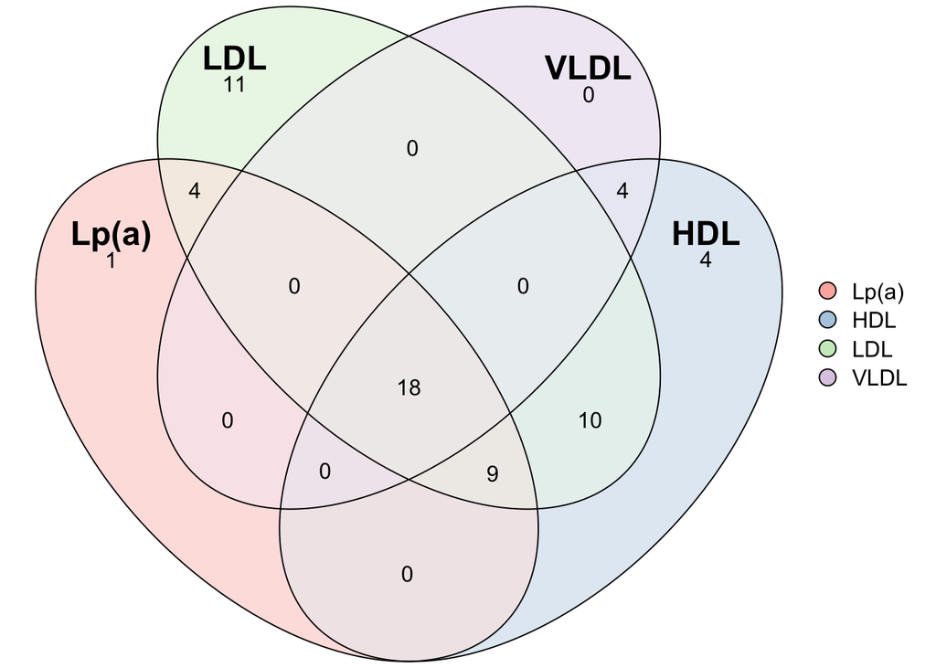

```r
# making venn diagram
venn <- venn(c('Lp(a)'=1,'HDL'=4,'LDL'=11,'VLDL'=0,
                 'LDL&HDL'=10,'LDL&HDL&Lp(a)'=9,'LDL&Lp(a)'=4,
                 'VLDL&HDL'=4,'VLDL&LDL&HDL&Lp(a)'=18))
plot(venn, fills=list(fill=brewer.pal(4,'Pastel1'), alpha=0.4), labels=list(fontsize=18),
     edges=list(edge='black', alpha=1), legend=list(color='black', alpha=1))
```

## PCA Plot

A principle component analysis was conducted, and score plots produced, to further investigate if there are distinct proteomic signatures for each lipoprotein species.

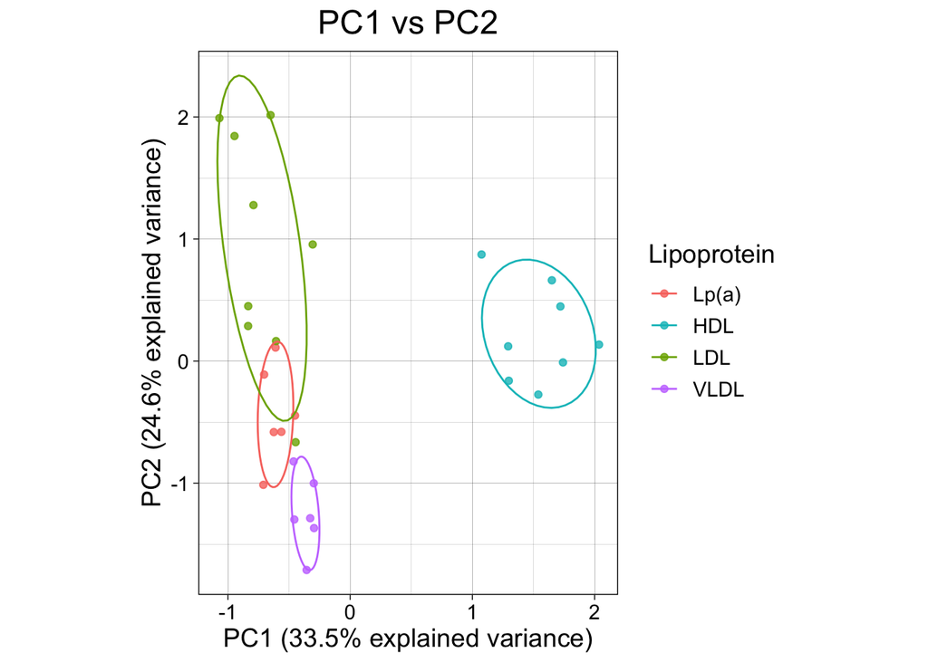

```r
# making data frame out of transposed dataset
lpa_trans <- read_excel("Lp(a) small volume isolation proteomics.xlsx", sheet="Transposed", col_names=TRUE)
pca <- data.frame(lpa_trans[,3:63])

# pca analysis (zeros included in dataset) and groups
pca <- prcomp(pca, center=TRUE, scale.=TRUE)
pca_type <- c(lpa_trans$Fraction)
pca_type <- factor(pca_type, levels=c("Lp(a)", "HDL", "LDL", "VLDL"))

# plotting PC1 vs PC2
ggbiplot::ggbiplot(pca,  groups=pca_type, choices=1:2, ellipse=TRUE, var.axes=FALSE, alpha=0.8) +
  labs(title='PC1 vs PC2', x='PC1 (33.5% explained variance)', y='PC2 (24.6% explained variance)', color='Lipoprotein') +
  #scale_color_brewer(palette="Pastel1") +
  scale_color_manual(values=c("#F8766D", "#00BFC4", "#7CAE00", "#C77CFF")) +
  theme_linedraw() +
  theme(plot.title=element_text(hjust=0.5, size=18), plot.subtitle=element_text(hjust=0.5, size=12), text=element_text(size=14))
```

## Heat Map

Relative protein abundance was calculated as z-scores that were generated from adjusted spectral counts. Red, upregulated; blue, downregulated. Samples and proteins were clustered by complete Euclidian hierarchical cluster analysis.

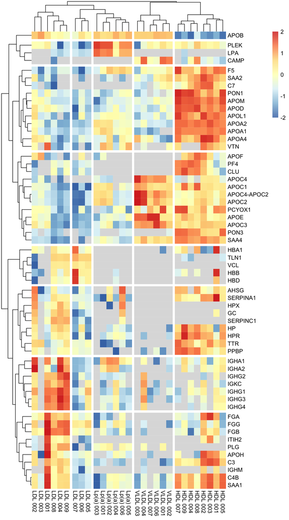

```r
# import data from excel
lpa_75 <- read_excel("Lp(a) small volume isolation proteomics.xlsx", sheet="Working list", col_names=TRUE)
protdata <- as.matrix(lpa_75[,-1])
protdata[protdata == 0] <- NA
rownames <- lpa_75[,1]
annotation_row <- data.frame(rownames)
rownames(protdata) <- annotation_row$Protein

# identify & remove rows giving NAs w/distance calculation
giveNAs <- which(is.na(as.matrix(dist(protdata))), arr.ind=TRUE)
tab <- sort(table(c(giveNAs)), decreasing=TRUE)
checkNA <- sapply(1:length(tab), function(i){
  sum(is.na(as.matrix(dist(protdata[-as.numeric(names(tab[1:i])),]))))
})
rmv <- names(tab)[1:min(which(checkNA==0))]
protdata <- protdata[-as.numeric(rmv),]

# plot
pheatmap(log10(protdata), scale="row", border_color=NA, breaks=seq(-2,2,.01), color=colorRampPalette(rev(brewer.pal(n=7, name="RdYlBu")))(400),
         cluster_cols=TRUE, cluster_rows=TRUE, cutree_cols=5, cutree_rows=8)
```

## Volcano Plots

For comparisons between specific lipoprotein groups, significant changes in protein abundance was determined by an unpaired two-sided t-test, followed by Benjamini-Hochberg correction for multiple comparisons. A differentially expressed protein was selected by having greater than 2-fold change and adjusted P value < 0.05.

### Lp(a) vs HDL

**Note:** All comparisons are relative to HDL - i.e. Lp(a) has significantly *more* APOB and significantly *less* APOA1 than HDL

#### BH-adjusted P values

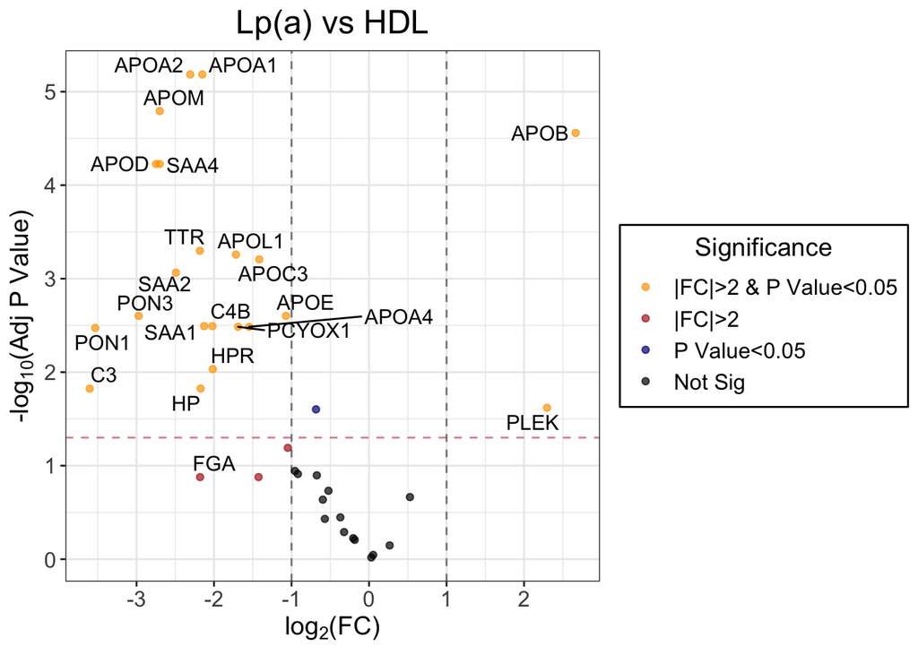

#### Non-adjusted P values

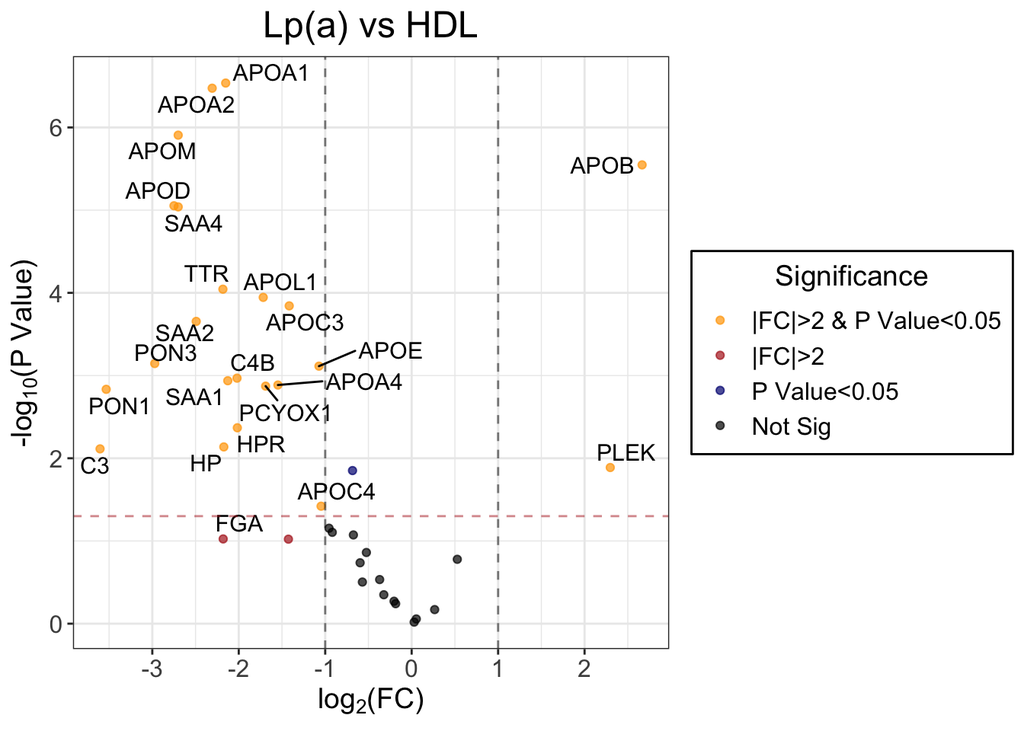

#### Supplemental Table: Fold Change & P Values

```r
# making new table with desired data & names
hdl_t <- data.frame("Protein"=hdl$Protein, "Mean HDL"=format(lpa_hdl$mean.hdl, digits=3, nsmall=0), "Mean Lp(a)"=lpa_hdl$mean.lpa, "Fold Change"=lpa_hdl$FC,
                    "P-Value"=lpa_hdl$p.value, "BH P-Value"=hdl$AdjPValue, check.names=FALSE, stringsAsFactors=FALSE)

# writing a scrollable embedded html table
kbl(hdl_t, caption="Lp(a) vs HDL") %>%
  row_spec(0, bold=TRUE) %>%
  kable_classic(full_width=F, html_font="Times New Roman")
```

Lp(a) vs HDL

| Protein | Mean HDL | Mean Lp(a) | Fold Change | P-Value | BH P-Value |
| --- | --- | --- | --- | --- | --- |
| APOA1 | 0.255489 | 0.0575216 | 0.2251430 | 0.0000003 | 0.0000065 |
| APOA2 | 0.028288 | 0.0057150 | 0.2020273 | 0.0000003 | 0.0000065 |
| APOM | 0.017722 | 0.0027263 | 0.1538378 | 0.0000012 | 0.0000161 |
| APOB | 0.094664 | 0.6005428 | 6.3439702 | 0.0000028 | 0.0000277 |
| APOD | 0.010772 | 0.0016019 | 0.1487190 | 0.0000089 | 0.0000594 |
| SAA4 | 0.008999 | 0.0013844 | 0.1538444 | 0.0000091 | 0.0000594 |
| TTR | 0.003812 | 0.0008392 | 0.2201665 | 0.0000903 | 0.0005033 |
| APOL1 | 0.003622 | 0.0011017 | 0.3041667 | 0.0001135 | 0.0005531 |
| APOC3 | 0.012096 | 0.0045319 | 0.3746766 | 0.0001437 | 0.0006226 |
| SAA2 | 0.004974 | 0.0008841 | 0.1777414 | 0.0002214 | 0.0008636 |
| PON3 | 0.003481 | 0.0004436 | 0.1274407 | 0.0007157 | 0.0025018 |
| APOE | 0.018698 | 0.0088925 | 0.4755900 | 0.0007698 | 0.0025018 |
| C4B | 0.009863 | 0.0024318 | 0.2465582 | 0.0010749 | 0.0032176 |
| SAA1 | 0.009676 | 0.0022152 | 0.2289325 | 0.0011550 | 0.0032176 |
| APOA4 | 0.016004 | 0.0054767 | 0.3422084 | 0.0013013 | 0.0032719 |
| PCYOX1 | 0.004552 | 0.0014119 | 0.3101447 | 0.0013423 | 0.0032719 |
| PON1 | 0.014927 | 0.0012894 | 0.0863767 | 0.0014668 | 0.0033649 |
| HPR | 0.006453 | 0.0015950 | 0.2471656 | 0.0042787 | 0.0092705 |
| HP | 0.005357 | 0.0011881 | 0.2217606 | 0.0072930 | 0.0149699 |
| C3 | 0.018216 | 0.0014978 | 0.0822237 | 0.0076987 | 0.0150124 |
| PLEK | 0.019819 | 0.0974042 | 4.9147900 | 0.0129411 | 0.0240335 |
| F5 | 0.006412 | 0.0039904 | 0.6223421 | 0.0140890 | 0.0249760 |
| APOC4 | 0.001656 | 0.0008010 | 0.4836966 | 0.0379897 | 0.0644173 |
| APOF | 0.001095 | 0.0005644 | 0.5155747 | 0.0701336 | 0.1139671 |
| APOH | 0.002238 | 0.0011843 | 0.5291304 | 0.0786270 | 0.1226582 |
| APOC1 | 0.003349 | 0.0020991 | 0.6267130 | 0.0845664 | 0.1268496 |
| FGA | 0.005514 | 0.0012166 | 0.2206297 | 0.0945110 | 0.1324455 |
| SERPINA1 | 0.010082 | 0.0037527 | 0.3722246 | 0.0950891 | 0.1324455 |
| VTN | 0.001827 | 0.0012706 | 0.6955544 | 0.1378750 | 0.1854182 |
| IGHA1 | 0.001368 | 0.0019723 | 1.4417069 | 0.1666001 | 0.2165801 |
| FGB | 0.002351 | 0.0015548 | 0.6614033 | 0.1835292 | 0.2308916 |
| IGHG3 | 0.001238 | 0.0009580 | 0.7736657 | 0.2929536 | 0.3570372 |
| IGHG1 | 0.001941 | 0.0013074 | 0.6735751 | 0.3137585 | 0.3708055 |
| IGHG4 | 0.001063 | 0.0008500 | 0.7998346 | 0.4470351 | 0.5127756 |
| APOC4-APOC2 | 0.002985 | 0.0025919 | 0.8683210 | 0.5354473 | 0.5966412 |
| APOC2 | 0.002907 | 0.0025569 | 0.8794529 | 0.5734585 | 0.6212467 |
| AHSG | 0.001535 | 0.0018453 | 1.2024329 | 0.6757793 | 0.7123079 |
| IGHA2 | 0.000849 | 0.0008810 | 1.0377577 | 0.8769395 | 0.9000169 |
| FGG | 0.001937 | 0.0019767 | 1.0203583 | 0.9576774 | 0.9576774 |

### Lp(a) vs LDL

**Note:** All comparisons are relative to LDL - i.e. Lp(a) has significantly *more* LPA and significantly *less* C3 than LDL

#### BH-adjusted P values

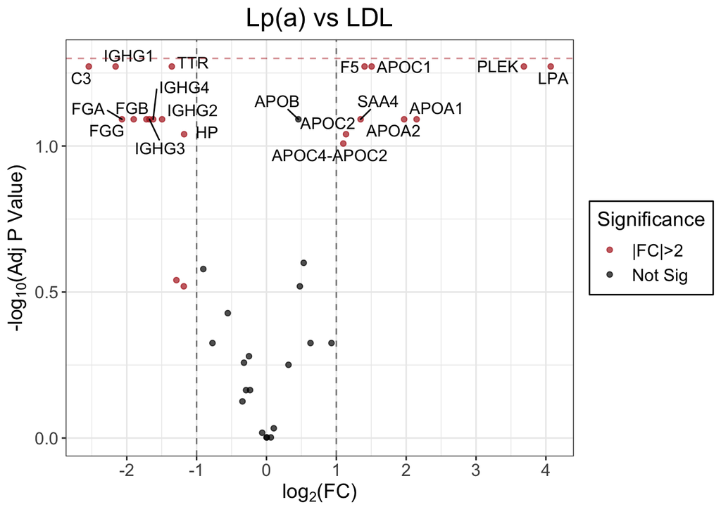

#### Non-adjusted P values

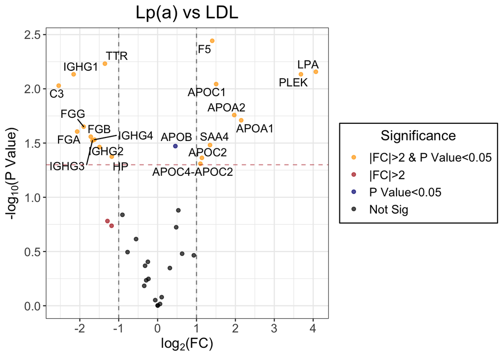

#### Supplemental Table: Fold Change & P Values

```r
# making new table with desired data & names
ldl_t <- data.frame("Protein"=ldl$Protein, "Mean LDL"=lpa_ldl$mean.ldl, "Mean Lp(a)"=lpa_ldl$mean.lpa, "Fold Change"=lpa_ldl$FC,
                    "P-Value"=lpa_ldl$p.value, "BH P-Value"=ldl$AdjPValue, check.names=FALSE, stringsAsFactors=FALSE)

# making a scrollable embedded html table
kbl(ldl_t, caption="Lp(a) vs LDL") %>%
  row_spec(0, bold=TRUE) %>%
  kable_classic(full_width=F, html_font="Times New Roman")
```

Lp(a) vs LDL

| Protein | Mean LDL | Mean Lp(a) | Fold Change | P-Value | BH P-Value |
| --- | --- | --- | --- | --- | --- |
| F5 | 0.0015079 | 0.0039904 | 2.6463841 | 0.0036067 | 0.0534136 |
| TTR | 0.0021467 | 0.0008392 | 0.3909124 | 0.0058623 | 0.0534136 |
| LPA | 0.0056633 | 0.0950619 | 16.7854910 | 0.0069633 | 0.0534136 |
| PLEK | 0.0075738 | 0.0974042 | 12.8607161 | 0.0073415 | 0.0534136 |
| IGHG1 | 0.0058414 | 0.0013074 | 0.2238140 | 0.0073431 | 0.0534136 |
| APOC1 | 0.0007395 | 0.0020991 | 2.8385626 | 0.0090421 | 0.0534136 |
| C3 | 0.0087336 | 0.0014978 | 0.1714933 | 0.0093474 | 0.0534136 |
| APOA2 | 0.0014581 | 0.0057150 | 3.9195099 | 0.0174467 | 0.0809929 |
| APOA1 | 0.0129667 | 0.0575216 | 4.4360858 | 0.0194944 | 0.0809929 |
| FGG | 0.0073809 | 0.0019767 | 0.2678154 | 0.0223499 | 0.0809929 |
| FGA | 0.0051034 | 0.0012166 | 0.2383816 | 0.0247713 | 0.0809929 |
| FGB | 0.0051169 | 0.0015548 | 0.3038453 | 0.0276265 | 0.0809929 |
| IGHG4 | 0.0026167 | 0.0008500 | 0.3248243 | 0.0294144 | 0.0809929 |
| IGHG3 | 0.0030610 | 0.0009580 | 0.3129813 | 0.0300356 | 0.0809929 |
| SAA4 | 0.0005441 | 0.0013844 | 2.5445250 | 0.0329973 | 0.0809929 |
| APOB | 0.4375417 | 0.6005428 | 1.3725383 | 0.0337377 | 0.0809929 |
| IGHG2 | 0.0021011 | 0.0007457 | 0.3549083 | 0.0344220 | 0.0809929 |
| HP | 0.0026902 | 0.0011881 | 0.4416359 | 0.0421757 | 0.0911060 |
| APOC2 | 0.0011612 | 0.0025569 | 2.2018965 | 0.0432754 | 0.0911060 |
| APOC4-APOC2 | 0.0012093 | 0.0025919 | 2.1432212 | 0.0490332 | 0.0980665 |
| APOE | 0.0061454 | 0.0088925 | 1.4470161 | 0.1318974 | 0.2512331 |
| IGKC | 0.0022346 | 0.0011937 | 0.5342086 | 0.1450845 | 0.2637899 |
| SAA1 | 0.0054150 | 0.0022152 | 0.4090909 | 0.1655730 | 0.2879531 |
| C4B | 0.0055238 | 0.0024318 | 0.4402383 | 0.1830824 | 0.3022823 |
| APOL1 | 0.0007910 | 0.0011017 | 1.3928232 | 0.1889264 | 0.3022823 |
| APOH | 0.0017386 | 0.0011843 | 0.6811828 | 0.2427862 | 0.3735172 |
| PLG | 0.0027397 | 0.0016032 | 0.5851759 | 0.3201234 | 0.4728201 |
| VTN | 0.0008209 | 0.0012706 | 1.5477745 | 0.3312068 | 0.4728201 |
| AHSG | 0.0009680 | 0.0018453 | 1.9062879 | 0.3427945 | 0.4728201 |
| APOM | 0.0032435 | 0.0027263 | 0.8405556 | 0.3934735 | 0.5246313 |
| APOD | 0.0020026 | 0.0016019 | 0.7999134 | 0.4278327 | 0.5520422 |
| APOA4 | 0.0044023 | 0.0054767 | 1.2440569 | 0.4491330 | 0.5614162 |
| HPR | 0.0018772 | 0.0015950 | 0.8497012 | 0.5652389 | 0.6851381 |
| IGHA2 | 0.0010790 | 0.0008810 | 0.8164887 | 0.5826289 | 0.6854458 |
| SERPINA1 | 0.0047634 | 0.0037527 | 0.7878271 | 0.6553731 | 0.7489979 |
| APOC3 | 0.0042150 | 0.0045319 | 1.0752035 | 0.8332316 | 0.9258129 |
| IGHA1 | 0.0020579 | 0.0019723 | 0.9584111 | 0.8873172 | 0.9592618 |
| HPX | 0.0021906 | 0.0022876 | 1.0442494 | 0.9626467 | 0.9952340 |
| PON1 | 0.0012864 | 0.0012894 | 1.0022913 | 0.9938346 | 0.9952340 |
| PCYOX1 | 0.0014097 | 0.0014119 | 1.0015824 | 0.9952340 | 0.9952340 |

### Lp(a) vs VLDL

**Note:** All comparisons are relative to VLDL - i.e. Lp(a) has significantly *more* APOA1 and significantly *less* APOC3 than VLDL

#### BH-adjusted P values

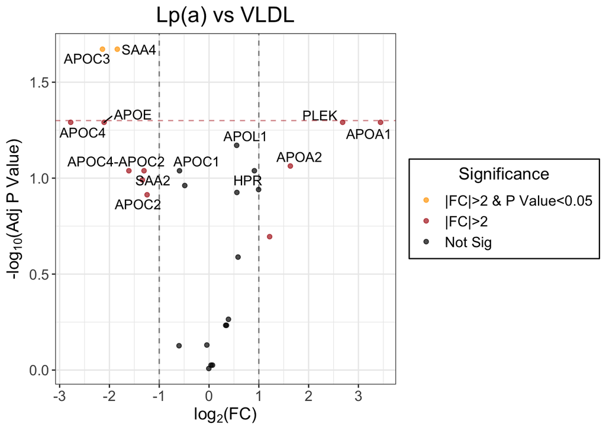

#### Non-adjusted P values

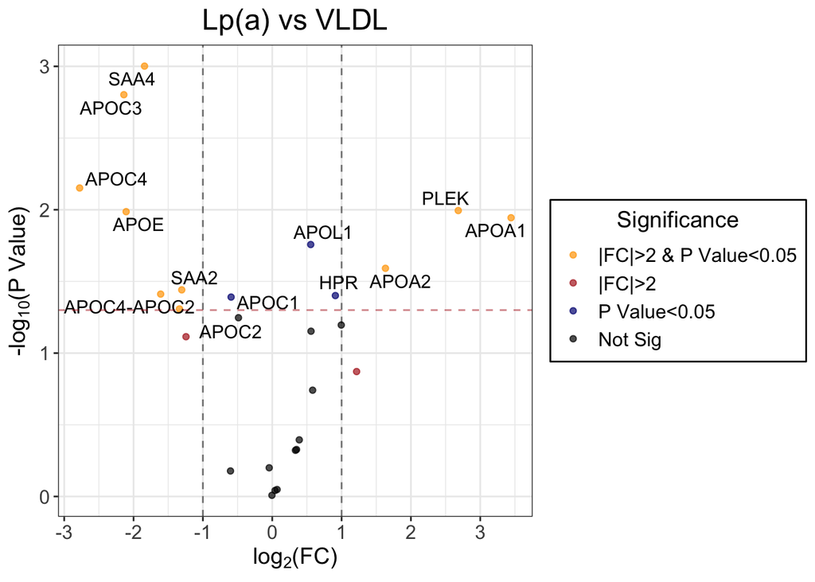

#### Supplemental Table: Fold Change & P Values

```r
# making new table with desired data & names
vldl_t <- data.frame("Protein"=vldl$Protein, "Fold Change"=lpa_vldl$FC, "Mean VLDL"=lpa_vldl$mean.vldl, "Mean Lp(a)"=lpa_vldl$mean.lpa,
                     "P-Value"=lpa_vldl$p.value, "BH P-Value"=vldl$AdjPValue, check.names=FALSE, stringsAsFactors=FALSE)

# writing a scrollable embedded html table
kbl(vldl_t, caption="Lp(a) vs VLDL") %>%
  row_spec(0, bold=TRUE) %>%
  kable_classic(full_width=F, html_font="Times New Roman")
```

Lp(a) vs VLDL

| Protein | Fold Change | Mean VLDL | Mean Lp(a) | P-Value | BH P-Value |
| --- | --- | --- | --- | --- | --- |
| SAA4 | 0.2789577 | 0.0049627 | 0.0013844 | 0.0009964 | 0.0212845 |
| APOC3 | 0.2269034 | 0.0199730 | 0.0045319 | 0.0015766 | 0.0212845 |
| APOC4 | 0.1458206 | 0.0054930 | 0.0008010 | 0.0070516 | 0.0511754 |
| PLEK | 6.4212369 | 0.0151691 | 0.0974042 | 0.0101330 | 0.0511754 |
| APOE | 0.2321161 | 0.0383105 | 0.0088925 | 0.0103169 | 0.0511754 |
| APOA1 | 10.8840867 | 0.0052849 | 0.0575216 | 0.0113723 | 0.0511754 |
| APOL1 | 1.4691130 | 0.0007499 | 0.0011017 | 0.0174898 | 0.0674606 |
| APOA2 | 3.1011198 | 0.0018429 | 0.0057150 | 0.0256157 | 0.0864531 |
| SAA2 | 0.4046893 | 0.0021846 | 0.0008841 | 0.0362178 | 0.0914908 |
| APOC4-APOC2 | 0.3277689 | 0.0079076 | 0.0025919 | 0.0387614 | 0.0914908 |
| HPR | 1.8797488 | 0.0008485 | 0.0015950 | 0.0396959 | 0.0914908 |
| APOC1 | 0.6628594 | 0.0031668 | 0.0020991 | 0.0406626 | 0.0914908 |
| PCYOX1 | 0.3955750 | 0.0035692 | 0.0014119 | 0.0491900 | 0.1021638 |
| APOM | 0.7134697 | 0.0038212 | 0.0027263 | 0.0566530 | 0.1092594 |
| IGHA1 | 1.9936282 | 0.0009893 | 0.0019723 | 0.0636968 | 0.1146543 |
| F5 | 1.4737150 | 0.0027077 | 0.0039904 | 0.0703570 | 0.1187274 |
| APOC2 | 0.4222576 | 0.0060552 | 0.0025569 | 0.0768485 | 0.1220535 |
| FGG | 2.3242568 | 0.0008505 | 0.0019767 | 0.1345025 | 0.2017537 |
| VTN | 1.4973756 | 0.0008485 | 0.0012706 | 0.1813995 | 0.2577783 |
| PON1 | 1.3101949 | 0.0009841 | 0.0012894 | 0.4027736 | 0.5437444 |
| C4B | 1.2750352 | 0.0019072 | 0.0024318 | 0.4704842 | 0.5845192 |
| SAA1 | 1.2611201 | 0.0017566 | 0.0022152 | 0.4762749 | 0.5845192 |
| APOB | 0.9701695 | 0.6190082 | 0.6005428 | 0.6307042 | 0.7403919 |
| IGHG3 | 0.6587881 | 0.0014543 | 0.0009580 | 0.6637269 | 0.7466928 |
| APOA4 | 1.0496438 | 0.0052177 | 0.0054767 | 0.8942566 | 0.9425225 |
| APOD | 1.0285065 | 0.0015575 | 0.0016019 | 0.9076142 | 0.9425225 |
| PLG | 0.9969591 | 0.0016081 | 0.0016032 | 0.9812837 | 0.9812837 |

### LDL vs HDL

**Note:** All comparisons are relative to HDL - i.e. LDL has significantly *more* TLN1 & APOB and significantly *less* APOA1 than HDL

#### BH-adjusted P values

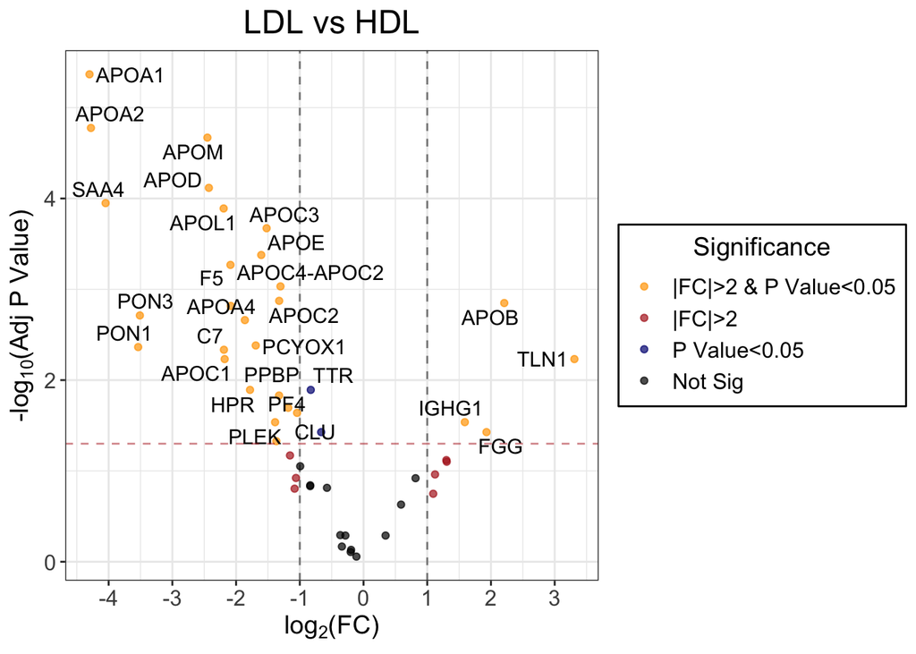

#### Non-adjusted P values

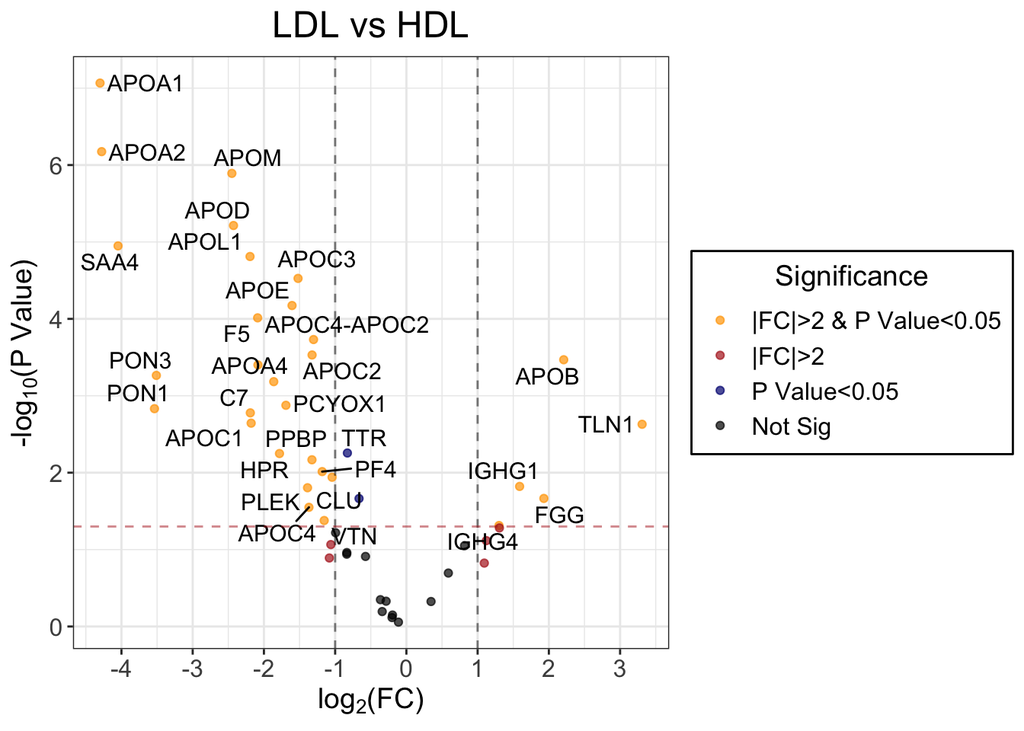

#### Supplmental Table: Fold Change & P Values

```r
# making new table with desired data & names
ldl_hdl_t <- data.frame("Protein"=ldlhdl$Protein, "Fold Change"=ldl_hdl$FC, "Mean HDL"=ldl_hdl$mean.hdl, "Mean LDL"=ldl_hdl$mean.ldl,
                        "P-Value"=ldl_hdl$p.value, "BH P-Value"=ldlhdl$AdjPValue, check.names=FALSE, stringsAsFactors=FALSE)

# writing a scrollable embedded html table
kbl(ldl_hdl_t, caption="LDL vs HDL") %>%
  row_spec(0, bold=TRUE) %>%
  kable_classic(full_width=F, html_font="Times New Roman")
```

LDL vs HDL

| Protein | Fold Change | Mean HDL | Mean LDL | P-Value | BH P-Value |
| --- | --- | --- | --- | --- | --- |
| APOA1 | 0.0507526 | 0.2554892 | 0.0129667 | 0.0000001 | 0.0000043 |
| APOA2 | 0.0515440 | 0.0282881 | 0.0014581 | 0.0000007 | 0.0000167 |
| APOM | 0.1830192 | 0.0177220 | 0.0032435 | 0.0000013 | 0.0000214 |
| APOD | 0.1859188 | 0.0107716 | 0.0020026 | 0.0000061 | 0.0000764 |
| SAA4 | 0.0604610 | 0.0089986 | 0.0005441 | 0.0000113 | 0.0001125 |
| APOL1 | 0.2183814 | 0.0036221 | 0.0007910 | 0.0000155 | 0.0001288 |
| APOC3 | 0.3484704 | 0.0120956 | 0.0042150 | 0.0000298 | 0.0002127 |
| APOE | 0.3286694 | 0.0186978 | 0.0061454 | 0.0000671 | 0.0004192 |
| F5 | 0.2351670 | 0.0064120 | 0.0015079 | 0.0000970 | 0.0005387 |
| APOC4-APOC2 | 0.4051476 | 0.0029849 | 0.0012093 | 0.0001857 | 0.0009287 |
| APOC2 | 0.3994070 | 0.0029073 | 0.0011612 | 0.0002948 | 0.0013401 |
| APOB | 4.6220716 | 0.0946636 | 0.4375417 | 0.0003400 | 0.0014168 |
| SAA2 | 0.2358981 | 0.0049741 | 0.0011734 | 0.0003967 | 0.0015256 |
| PON3 | 0.0877747 | 0.0034812 | 0.0003056 | 0.0005434 | 0.0019408 |
| APOA4 | 0.2750746 | 0.0160041 | 0.0044023 | 0.0006550 | 0.0021834 |
| PCYOX1 | 0.3096547 | 0.0045523 | 0.0014097 | 0.0013295 | 0.0041548 |
| PON1 | 0.0861792 | 0.0149274 | 0.0012864 | 0.0014712 | 0.0043270 |
| C7 | 0.2190051 | 0.0025462 | 0.0005576 | 0.0016674 | 0.0046318 |
| APOC1 | 0.2207853 | 0.0033494 | 0.0007395 | 0.0022697 | 0.0058680 |
| TLN1 | 9.9100295 | 0.0016990 | 0.0168368 | 0.0023472 | 0.0058680 |
| TTR | 0.5632119 | 0.0038115 | 0.0021467 | 0.0055477 | 0.0128121 |
| HPR | 0.2908853 | 0.0064532 | 0.0018772 | 0.0056373 | 0.0128121 |
| PPBP | 0.3989455 | 0.0073913 | 0.0029487 | 0.0067963 | 0.0147747 |
| PF4 | 0.4406852 | 0.0033549 | 0.0014785 | 0.0096806 | 0.0201678 |
| CLU | 0.4853080 | 0.0020004 | 0.0009708 | 0.0114646 | 0.0229292 |
| IGHG1 | 3.0095304 | 0.0019410 | 0.0058414 | 0.0150889 | 0.0290172 |
| PLEK | 0.3821552 | 0.0198186 | 0.0075738 | 0.0156968 | 0.0290681 |
| FGG | 3.8099319 | 0.0019373 | 0.0073809 | 0.0216120 | 0.0373815 |
| AHSG | 0.6307719 | 0.0015346 | 0.0009680 | 0.0216812 | 0.0373815 |
| APOC4 | 0.3874323 | 0.0016560 | 0.0006416 | 0.0281947 | 0.0469911 |
| VTN | 0.4493900 | 0.0018267 | 0.0008209 | 0.0418610 | 0.0675177 |
| IGHG4 | 2.4623605 | 0.0010627 | 0.0026167 | 0.0486475 | 0.0760118 |
| IGHG3 | 2.4719229 | 0.0012383 | 0.0030610 | 0.0522555 | 0.0791749 |
| HP | 0.5021344 | 0.0053575 | 0.0026902 | 0.0603653 | 0.0887725 |
| FGB | 2.1767765 | 0.0023507 | 0.0051169 | 0.0764912 | 0.1092731 |
| C3 | 0.4794575 | 0.0182157 | 0.0087336 | 0.0860693 | 0.1195407 |
| IGKC | 1.7610036 | 0.0012689 | 0.0022346 | 0.0889671 | 0.1202258 |
| C4B | 0.5600562 | 0.0098629 | 0.0055238 | 0.1093310 | 0.1438566 |
| SAA1 | 0.5596127 | 0.0096763 | 0.0054150 | 0.1147204 | 0.1470775 |
| APOF | 0.6717893 | 0.0010948 | 0.0007355 | 0.1227757 | 0.1534696 |
| SERPINA1 | 0.4724699 | 0.0100818 | 0.0047634 | 0.1285459 | 0.1567633 |
| IGHG2 | 2.1341471 | 0.0009845 | 0.0021011 | 0.1498063 | 0.1783408 |
| IGHA1 | 1.5042678 | 0.0013680 | 0.0020579 | 0.2018513 | 0.2347108 |
| APOH | 0.7767819 | 0.0022383 | 0.0017386 | 0.4481153 | 0.5092219 |
| IGHM | 0.8207659 | 0.0024153 | 0.0019824 | 0.4690552 | 0.5144671 |
| IGHA2 | 1.2710008 | 0.0008489 | 0.0010790 | 0.4733098 | 0.5144671 |
| ITIH2 | 0.7902058 | 0.0014638 | 0.0011567 | 0.6391802 | 0.6799789 |
| HBA1 | 0.8734800 | 0.0019804 | 0.0017299 | 0.7095172 | 0.7390805 |
| HBB | 0.8695872 | 0.0019913 | 0.0017316 | 0.7652329 | 0.7808499 |
| FGA | 0.9255318 | 0.0055140 | 0.0051034 | 0.8769678 | 0.8769678 |

## Supplemental Bar Graphs: LPA & APOB

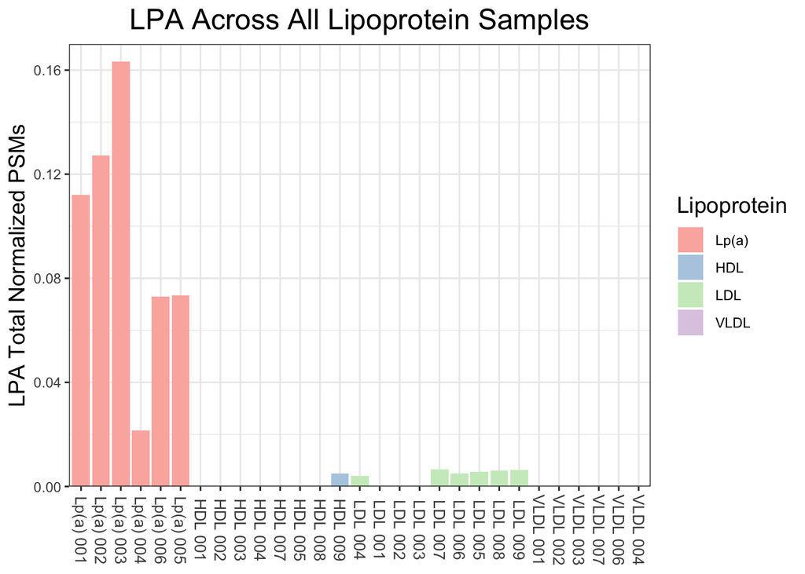

```r
# importing and organizing data
lpa_trans <- read_excel("Lp(a) small volume isolation proteomics.xlsx", sheet="Transposed", col_names=TRUE)
bar <- data.frame("Lipoprotein"=lpa_trans$Fraction, "Sample"=lpa_trans$Sample, "LPA"=lpa_trans$LPA, "APOB"=lpa_trans$APOB)
bar$Lipoprotein <- factor(bar$Lipoprotein, levels=c("Lp(a)","HDL","LDL","VLDL"))
bar$Sample <- factor(bar$Sample, levels=bar$Sample)

# plotting LPA
ggplot(bar, aes(x=Sample, y=LPA, fill=Lipoprotein)) +
  geom_bar(stat="identity", position=position_dodge()) +
  scale_y_continuous(expand=c(0,0), limits=c(0,0.17)) +
  scale_fill_brewer(palette="Pastel1") +
  labs(title="LPA Across All Lipoprotein Samples", y="LPA Total Normalized PSMs", x=NULL) +
  theme_bw() +
  theme(plot.title=element_text(hjust=0.5, size=18), axis.title.y=element_text(size=14), axis.text.x=element_text(angle=270, vjust=0.5, size=10),
        legend.title=element_text(size=14))
```

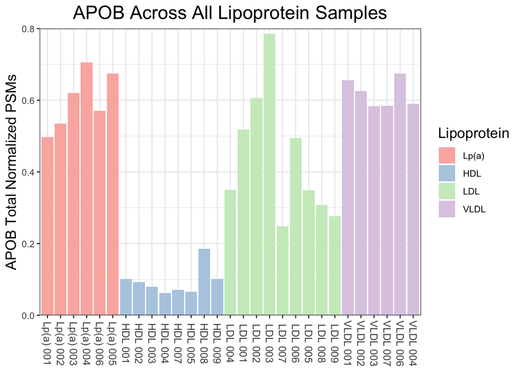

```r
# plotting APOB
ggplot(bar, aes(x=Sample, y=APOB, fill=Lipoprotein)) +
  geom_bar(stat="identity", position=position_dodge()) +
  scale_y_continuous(expand=c(0,0), limits=c(0,0.8)) +
  scale_fill_brewer(palette="Pastel1") +
  labs(title="APOB Across All Lipoprotein Samples", y="APOB Total Normalized PSMs", x=NULL) +
  theme_bw() +
  theme(plot.title=element_text(hjust=0.5, size=18), axis.title.y=element_text(size=14), axis.text.x=element_text(angle=270, vjust=0.5, size=10),
        legend.title=element_text(size=14))
```